# ch08_03E_cancer_lightGBM_CrossVal

### 위스콘신 유방암 데이터 셋 - LightGBM 모델 구현

### 학습 목표

- LightGBM 모델을 이용하여 학습과 예측을 수행해 본다.
- 예측을 수행한 결과에 대해 평가를 수행해 본다.(교차검증)

### 학습 내용

- LightGBM 모델 만들기 - 위스콘신 유방암 데이터 셋
- 평가해보기

### 목차

01 데이터 로드 및 전처리  
02 LightGBM 모델  
03 피처 중요도 시각화  
04 교차 검증  
05 모델 평가 - 교차 검증, GridSearchCV()

### 01 데이터 로드 및 전처리

목차로 이동하기

- 라이브러리가 없다고 확인되면 설치를 진행
  - (예) pip install lightgbm

```python
import pandas as pd
from sklearn.datasets import load_breast_cancer
import matplotlib.pyplot as plt
import matplotlib

import lightgbm as lgbm
import sklearn as sk
from lightgbm import LGBMClassifier
from sklearn.model_selection import train_test_split
```

```python
print("LightGBM : ", lgbm.__version__)
print("Scikit-learn : ", sk.__version__)
print("pandas : ", pd.__version__)
```

```
LightGBM :  3.3.5
Scikit-learn :  1.0.2
pandas :  1.4.4
```

```python
cancer = load_breast_cancer()

cancer_df = pd.DataFrame(cancer.data, columns=cancer.feature_names)
cancer_df.head()
```

|  | mean radius | mean texture | mean perimeter | mean area | mean smoothness | mean compactness | mean concavity | mean concave points | mean symmetry | mean fractal dimension | ... | worst radius | worst texture | worst perimeter | worst area | worst smoothness | worst compactness | worst concavity | worst concave points | worst symmetry | worst fractal dimension |
| --- | --- | --- | --- | --- | --- | --- | --- | --- | --- | --- | --- | --- | --- | --- | --- | --- | --- | --- | --- | --- | --- |
| 0 | 17.99 | 10.38 | 122.80 | 1001.0 | 0.11840 | 0.27760 | 0.3001 | 0.14710 | 0.2419 | 0.07871 | ... | 25.38 | 17.33 | 184.60 | 2019.0 | 0.1622 | 0.6656 | 0.7119 | 0.2654 | 0.4601 | 0.11890 |
| 1 | 20.57 | 17.77 | 132.90 | 1326.0 | 0.08474 | 0.07864 | 0.0869 | 0.07017 | 0.1812 | 0.05667 | ... | 24.99 | 23.41 | 158.80 | 1956.0 | 0.1238 | 0.1866 | 0.2416 | 0.1860 | 0.2750 | 0.08902 |
| 2 | 19.69 | 21.25 | 130.00 | 1203.0 | 0.10960 | 0.15990 | 0.1974 | 0.12790 | 0.2069 | 0.05999 | ... | 23.57 | 25.53 | 152.50 | 1709.0 | 0.1444 | 0.4245 | 0.4504 | 0.2430 | 0.3613 | 0.08758 |
| 3 | 11.42 | 20.38 | 77.58 | 386.1 | 0.14250 | 0.28390 | 0.2414 | 0.10520 | 0.2597 | 0.09744 | ... | 14.91 | 26.50 | 98.87 | 567.7 | 0.2098 | 0.8663 | 0.6869 | 0.2575 | 0.6638 | 0.17300 |
| 4 | 20.29 | 14.34 | 135.10 | 1297.0 | 0.10030 | 0.13280 | 0.1980 | 0.10430 | 0.1809 | 0.05883 | ... | 22.54 | 16.67 | 152.20 | 1575.0 | 0.1374 | 0.2050 | 0.4000 | 0.1625 | 0.2364 | 0.07678 |

5 rows × 30 columns

```python
print( cancer_df.shape)
```

```
(569, 30)
```

### 데이터 설명

- 위스콘신 유방암 데이터 세트는 유방암의 악성 종양, 양성 종양 여부를 결정하는 이진 분류
- 종양의 크기, 모양 등의 형태와 관련한 많은 피처를 가지고 있음.
- 569개의 행과, 30개의 피처로 이루어진 데이터
- null 값이 없음. 값들은 실수로 되어 있음.

### 데이터 나누기

```python
# 피처와 레이블를 지정.
X = cancer_df[:]
y = cancer.target

X.shape, y.shape
```

```
((569, 30), (569,))
```

```python
X_train , X_test, y_train, y_test = train_test_split(X, y,
                                           test_size=0.2, random_state=0)

X_train.shape, X_test.shape, y_train.shape, y_test.shape
```

```
((455, 30), (114, 30), (455,), (114,))
```

### 02 LightGBM 모델

목차로 이동하기

- LightGBM은 XGBoost와 부스팅 계열 알고리즘에서 가장 각광을 받고 있음.
- LightGBM은 가장 큰 장점은 XGBoost보다 학습에 걸리는 시간이 훨씬 적다. 메모리 사용량도 적다.
- LightGBM과 XGBoost의 예측 성능은 별다른 차이가 없음.
- LightGBM이 XGBoost보다 2년 후에 만들어짐.
- [단점] 적은 데이터 셋일 경우, 과적합이 발생할 가능성이 있음. (문서상에는 10000건 이하의 데이터로 기술하고 있음.)
- lightgbm 설치
  - pip install lightgbm

#### LightGBM의 파이썬 패키지인 lightgbm에서 LGBMClassifier 불러오기

```python
from lightgbm import LGBMClassifier
```

```python
# 모델 선택
model_lgbm = LGBMClassifier(n_estimators= 100)

# Lgbm은 중간에 조기 중단이 가능.
evals = [(X_test, y_test)]

# 모델 학습
model_lgbm.fit(X_train, y_train, early_stopping_rounds=100,
               eval_metric='logloss',
               eval_set=evals,
               verbose=True)

# 모델을 활용한 예측
preds = model_lgbm.predict(X_test)
pred_proba = model_lgbm.predict_proba(X_test)[:, 1]
```

```
[1]	valid_0's binary_logloss: 0.602575
[2]	valid_0's binary_logloss: 0.536123
[3]	valid_0's binary_logloss: 0.482224
[4]	valid_0's binary_logloss: 0.439121
[5]	valid_0's binary_logloss: 0.399484
[6]	valid_0's binary_logloss: 0.360741
[7]	valid_0's binary_logloss: 0.329635
[8]	valid_0's binary_logloss: 0.300259
[9]	valid_0's binary_logloss: 0.279599
[10]	valid_0's binary_logloss: 0.259173
[11]	valid_0's binary_logloss: 0.239127
[12]	valid_0's binary_logloss: 0.222309
[13]	valid_0's binary_logloss: 0.209351
[14]	valid_0's binary_logloss: 0.194316
[15]	valid_0's binary_logloss: 0.185282
[16]	valid_0's binary_logloss: 0.173675
[17]	valid_0's binary_logloss: 0.165308
[18]	valid_0's binary_logloss: 0.155769
[19]	valid_0's binary_logloss: 0.14865
[20]	valid_0's binary_logloss: 0.140995
[21]	valid_0's binary_logloss: 0.134334
[22]	valid_0's binary_logloss: 0.126574
[23]	valid_0's binary_logloss: 0.119264
[24]	valid_0's binary_logloss: 0.114799
[25]	valid_0's binary_logloss: 0.110568
[26]	valid_0's binary_logloss: 0.106157
[27]	valid_0's binary_logloss: 0.100816
[28]	valid_0's binary_logloss: 0.0978631
[29]	valid_0's binary_logloss: 0.0945873
[30]	valid_0's binary_logloss: 0.0916942
[31]	valid_0's binary_logloss: 0.0863612
[32]	valid_0's binary_logloss: 0.0822965
[33]	valid_0's binary_logloss: 0.078824
[34]	valid_0's binary_logloss: 0.0752847
[35]	valid_0's binary_logloss: 0.0718233
[36]	valid_0's binary_logloss: 0.0696371
[37]	valid_0's binary_logloss: 0.0676798
[38]	valid_0's binary_logloss: 0.0665177
[39]	valid_0's binary_logloss: 0.0660656
[40]	valid_0's binary_logloss: 0.064516
```

[output cut: 45 more lines]

```
[86]	valid_0's binary_logloss: 0.0632386
[87]	valid_0's binary_logloss: 0.0623831
[88]	valid_0's binary_logloss: 0.0611975
[89]	valid_0's binary_logloss: 0.060535
[90]	valid_0's binary_logloss: 0.0604596
[91]	valid_0's binary_logloss: 0.0594299
[92]	valid_0's binary_logloss: 0.0594986
[93]	valid_0's binary_logloss: 0.0599838
[94]	valid_0's binary_logloss: 0.05974
[95]	valid_0's binary_logloss: 0.0606709
[96]	valid_0's binary_logloss: 0.0607891
[97]	valid_0's binary_logloss: 0.062165
[98]	valid_0's binary_logloss: 0.0608996
[99]	valid_0's binary_logloss: 0.062041
[100]	valid_0's binary_logloss: 0.0608407
```

### 03 피처 중요도 시각화

목차로 이동하기

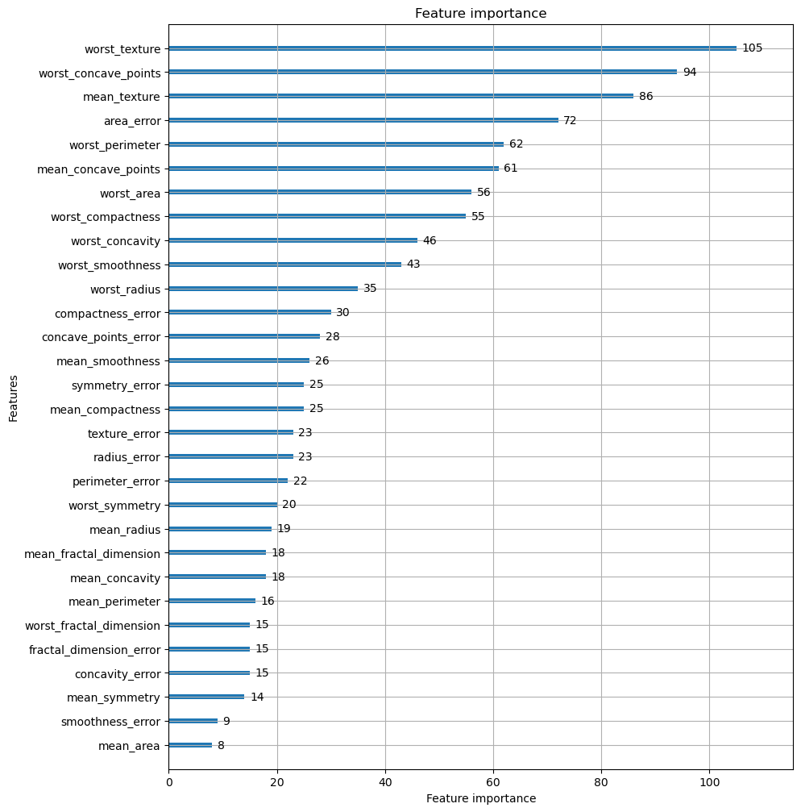

```python
from lightgbm import plot_importance
import matplotlib.pyplot as plt

fig, ax = plt.subplots(figsize=(10,12))
plot_importance(model_lgbm, ax=ax)
```

### 04 모델 평가 - 교차 검증

목차로 이동하기

```python
from sklearn.model_selection import cross_val_score
```

```python
def model_val_lgbm(model_name):
    model = model_name

    # Lgbm은 중간에 조기 중단이 가능.
    evals = [(X_test, y_test)]

    # 모델 학습
    model.fit(X_train, y_train, early_stopping_rounds=100,
               eval_metric='logloss',
               eval_set=evals,
               verbose=False)  # True는 학습 과정이 보임

    score = cross_val_score(model, X_test, y_test, cv=5, scoring="roc_auc")

    print("auc :", score)
    m_score = score.mean()      # 절대값
    print("auc 평균(cv=5) : ", m_score)
    return m_score
```

```python
# 모델 선택
model_lgbm = LGBMClassifier(n_estimators= 100,
                            learning_rate=0.1,
                             max_depth = 3)

score = model_val_lgbm(model_lgbm)
score
```

```
auc : [0.95384615 0.99230769 1.         0.98412698 0.97435897]
auc 평균(cv=5) :  0.980927960927961
```

```
0.980927960927961
```

### 05 모델 평가 - 교차 검증, GridSearchCV()

목차로 이동하기

```python
param_grid = {'max_depth':[3,5,7],
              'learning_rate':[0.1, 0.01, 0.001],
              'n_estimators':[100, 300, 500]}
print("매개변수 그리드 :\n", param_grid)
```

```
매개변수 그리드 :
 {'max_depth': [3, 5, 7], 'learning_rate': [0.1, 0.01, 0.001], 'n_estimators': [100, 300, 500]}
```

```python
from sklearn.model_selection import GridSearchCV
```

```python
grid_search = GridSearchCV(LGBMClassifier(),
                           param_grid, cv=5, return_train_score=True, scoring="roc_auc")
grid_search
```

```
GridSearchCV(cv=5, estimator=LGBMClassifier(),
             param_grid={'learning_rate': [0.1, 0.01, 0.001],
                         'max_depth': [3, 5, 7],
                         'n_estimators': [100, 300, 500]},
             return_train_score=True, scoring='roc_auc')
```

```python
# 찾기 학습
evals = [(X_test, y_test)]
grid_search.fit(X_train, y_train, early_stopping_rounds=100,
               eval_metric='logloss',
               eval_set=evals,
               verbose=False)  # True는 학습 과정이 보임)
```

[output not shown]

[output cut: 518 more lines]

```
GridSearchCV(cv=5, estimator=LGBMClassifier(),
             param_grid={'learning_rate': [0.1, 0.01, 0.001],
                         'max_depth': [3, 5, 7],
                         'n_estimators': [100, 300, 500]},
             return_train_score=True, scoring='roc_auc')
```

```python
best_model = grid_search.best_estimator_
best_params = grid_search.best_params_

best_model, best_params
```

```
(LGBMClassifier(max_depth=5, n_estimators=300),
 {'learning_rate': 0.1, 'max_depth': 5, 'n_estimators': 300})
```

```python
print("최적 매개변수 :", grid_search.best_params_)
print("최고 교차 검증 점수 : {:.4f}".format(grid_search.best_score_))
```

```
최적 매개변수 : {'learning_rate': 0.1, 'max_depth': 5, 'n_estimators': 300}
최고 교차 검증 점수 : 0.9935
```

### 정리

- gridSearchCV()를 이용하여 다양한 파라미터의 성능을 확인해 볼 수 있습니다.